# practical_exercise_7 , Methods 3, 2021, autumn semester

# Exercises and objectives

1. Estimate bias and variance based on a true underlying function
2. Fitting training data and applying it to test sets with and without regularization

# EXERCISE 1 - Estimate bias and variance based on a true underlying function

We can express regression as $y = f(x) + \epsilon$ with $E[\epsilon] = 0$ and $var(\epsilon) = \sigma^2$ ($E$ means expected value)

For a given point: $x_0$, we can decompose the expected prediction error , $E[(y_0 - \hat{f}(x_0))^2]$ into three parts - **bias**, **variance** and **irreducible error** (the first two together are the **reducible error**):

The expected prediction error is, which we also call the **Mean Squared Error**:  
$E[(y_0 - \hat{f}(x_0))^2] = bias(\hat{f}(x_0))^2 + var(\hat{f}(x_0)) + \sigma^2$

where **bias** is;

$bias(\hat{f}(x_0)) = E[\hat{f}(x_0)] - f(x_0)$

1. Create a function, $f(x)$ that squares its input. This is our **true** function
   1. generate data, $y$, based on an input range of [0, 6] with a spacing of 0.1. Call this $x$
   2. add normally distributed noise to $y$ with $\sigma=5$ (set a seed to 7 `np.random.seed(7)`) to $y$ and call it $y_{noisy}$
   3. plot the true function and the generated points
2. Fit a linear regression using `LinearRegression` from `sklearn.linear_model` based on $y_{noisy}$ and $x$ (see code chunk below associated with Exercise 1.2)
   1. plot the fitted line (see the `.intercept_` and `.coef_` attributes of the `regressor` object) on top of the plot (from 1.1.iii)
   2. now run the code chunk below associated with Exercise 1.2.ii - what does X_quadratic amount to?
   3. do a quadratic and a fifth order fit as well and plot them (on top of the plot from 1.2.i)
3. Simulate 100 samples, each with sample size `len(x)` with $\sigma=5$ normally distributed noise added on top of the true function
   1. do linear, quadratic and fifth-order fits for each of the 100 samples  
      ii create a **new** figure, `plt.figure`, and plot the linear and the quadratic fits (colour them appropriately); highlight the true value for $x_0=3$. From the graphics alone, judge which fit has the highest bias and which has the highest variance
   2. create a **new** figure, `plt.figure`, and plot the quadratic and the fifth-order fits (colour them appropriately); highlight the true value for $x_0=3$. From the graphics alone, judge which fit has the highest bias and which has the highest variance
   3. estimate the **bias** and **variance** at $x_0$ for the linear, the quadratic and the fifth-order fits (the expected value $E[\hat{f}(x_0)] - f(x_0)$ is found by taking the mean of all the simulated, $\hat{f}(x_0)$, differences)
   4. show how the **squared bias** and the **variance** is related to the complexity of the fitted models
   5. simulate **epsilon**: `epsilon = np.random.normal(scale=5, size=100)`. Based on your simulated values of **bias, variance and epsilon**, what is the **Mean Squared Error** for each of the three fits? Which fit is better according to this measure?

```python
# Exercise 1.2
from sklearn.linear_model import LinearRegression
regressor = LinearRegression()
regressor.fit() ## what goes in here?
```

```python
# Exercise 1.2.ii
from sklearn.linear_model import LinearRegression
from sklearn.preprocessing import PolynomialFeatures
quadratic = PolynomialFeatures(degree=2)
X_quadratic = quadratic.fit_transform(x.reshape(-1, 1))
regressor = LinearRegression()
regressor.fit() # what goes in here?
y_quadratic_hat # calculate this
```

1. Create a function, $f(x)$ that squares its input. This is our **true** function
   1. generate data, $y$, based on an input range of [0, 6] with a spacing of 0.1. Call this $x$
   2. add normally distributed noise to $y$ with $\sigma=5$ (set a seed to 7 `np.random.seed(7)`) to $y$ and call it $y_{noisy}$
   3. plot the true function and the generated points  
      **SOLUTION 1.1**

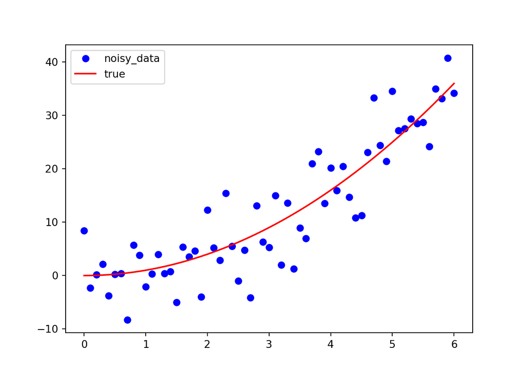

```python
import numpy as np
import matplotlib.pyplot as plt
from sklearn.linear_model import LinearRegression
from sklearn.preprocessing import PolynomialFeatures

# 1.1
def square(x):
    return(x**2)

# 1.1.i
x = np.arange(0, 6.1, 0.1) # "to but not including" in python
y_true = square(x) # The true relationship is f(x) = x^2

# 1.1.ii
np.random.seed(7)
noise = np.random.normal(scale=5, size=len(y_true)) # Generate noise
y_noise = y_true + noise # Add noise to true labels

# 1.1.ii
plt.figure() # Initialize new plot
plt.plot(x, y_noise, 'bo')
plt.plot(x, y_true, 'r-')
plt.legend(['noisy_data', 'true'])
plt.show()
```

2. Fit a linear regression using `LinearRegression` from `sklearn.linear_model` based on $y_{noisy}$ and $x$ (see code chunk below associated with Exercise 1.2)
   1. plot the fitted line (see the `.intercept_` and `.coef_` attributes of the `regressor` object) on top of the plot (from 1.1.iii)
   2. now run the code chunk below associated with Exercise 1.2.ii - what does X_quadratic amount to?
   3. do a quadratic and a fifth order fit as well and plot them (on top of the plot from 1.2.i)

**SOLUTION 1.2**

```python
# Exercise 1.2
from sklearn.linear_model import LinearRegression
regressor = LinearRegression() # Initialize a regressor (a class instantiation/class object)
x = x.reshape(-1, 1) # X variable has to match in format to sklearn -> each row should be new datapoint, while columns are for each feature of data
regressor.fit(x, y_noise) # Fit model

# 1.2.i
# Extract coefficients (look up sklearn.linear_model, documentation to know how) https://scikit-learn.org/stable/modules/generated/sklearn.linear_model.LinearRegression.html
```

```
## LinearRegression()
```

[output not shown]

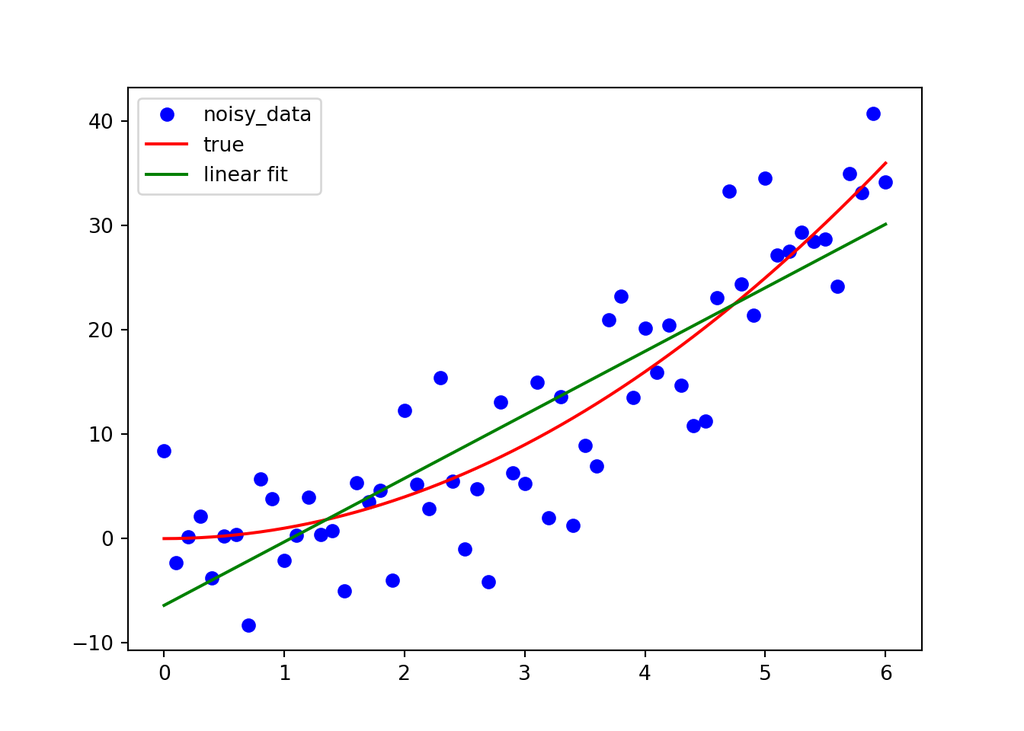

```python
beta0 = regressor.intercept_
beta1 = regressor.coef_[0]

# Get predictions
y_linear_hat = regressor.predict(x)
# or
y_linear_hat = beta0 + beta1 * x

# Plot predictions on top of previous plot (note that since we're not using a new "plt.figure" it just builds on top)
plt.figure() # Initialize new plot
plt.plot(x, y_noise, 'bo')
plt.plot(x, y_true, 'r-')
plt.plot(x, y_linear_hat, 'g-')
plt.legend(['noisy_data', 'true', 'linear fit'])
plt.show()

# 1.2.ii
```

```python
from sklearn.preprocessing import PolynomialFeatures
quadratic = PolynomialFeatures(degree=2) # Create an object / class instantiation, that may fit and transform to n-order polynomial x-values
X_quadratic = quadratic.fit_transform(x.reshape(-1, 1)) # From column vector x1, x2 ... xn, to matrix, with 1's in first column, x in second, and x**2

# What does X_quadratic amount to?
# A matrix of column1: 1's, column2: x, column3: x**2. In other words, the x-matrix we worked with last time, which is going to be multiplied into the vector b0, b1, b2

# 1.2.iii
# Train, fit, predict using quadratic
quadratic = PolynomialFeatures(degree=2)
X_quadratic = quadratic.fit_transform(x.reshape(-1, 1)) # transform the X, such that you get a third column of X^2
regressor = LinearRegression()
regressor.fit(X_quadratic, y_noise)
```

```
## LinearRegression()
```

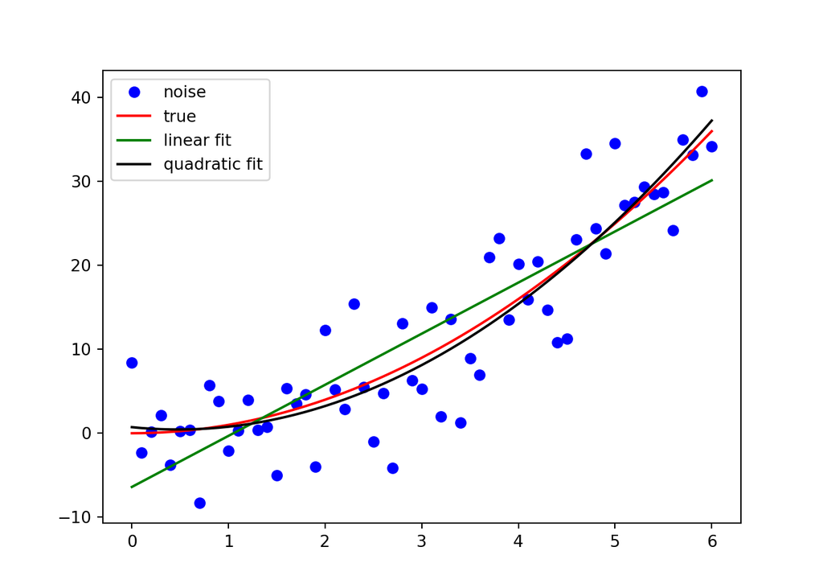

```python
y_quadratic_hat = regressor.intercept_ + regressor.coef_[1] * x + regressor.coef_[2] * x**2

# Plot
plt.figure() # Initialize new plot
plt.plot(x, y_noise, 'bo')
plt.plot(x, y_true, 'r-')
plt.plot(x, y_linear_hat, 'g-')
plt.plot(x, y_quadratic_hat, 'k-')
plt.legend(['noise', 'true', 'linear fit', 'quadratic fit'])
plt.show()

# Train, fit, predict using quintic
```

```python
fifth = PolynomialFeatures(degree=5)
X_fifth = fifth.fit_transform(x.reshape(-1, 1))
regressor = LinearRegression()
regressor.fit(X_fifth, y_noise)
```

```
## LinearRegression()
```

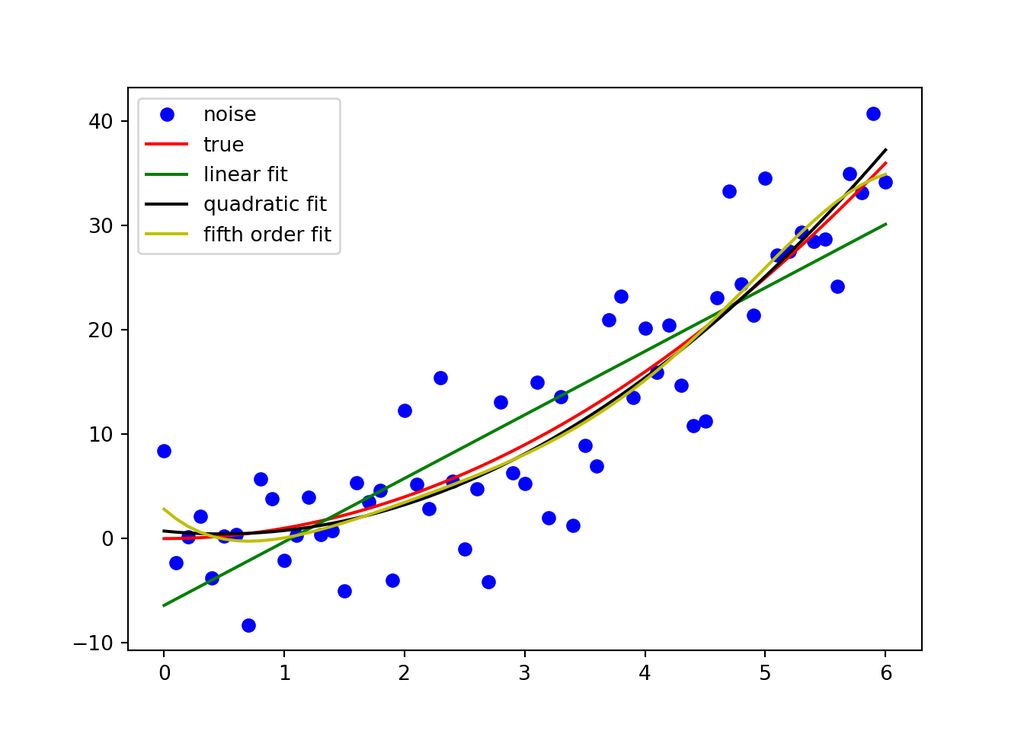

```python
y_fifth_hat = regressor.intercept_ + regressor.coef_[1] * x + regressor.coef_[2] * x**2 + regressor.coef_[3] * x**3 + regressor.coef_[4] * x**4 + regressor.coef_[5] * x**5

# Plot
plt.figure() # Initialize new plot
plt.plot(x, y_noise, 'bo')
plt.plot(x, y_true, 'r-')
plt.plot(x, y_linear_hat, 'g-')
plt.plot(x, y_quadratic_hat, 'k-')
plt.plot(x, y_fifth_hat, 'y-')
plt.legend(['noise', 'true', 'linear fit', 'quadratic fit', 'fifth order fit'])
plt.show()
```

3. Simulate 100 samples, each with sample size `len(x)` with $\sigma=5$ normally distributed noise added on top of the true function
   1. do linear, quadratic and fifth-order fits for each of the 100 samples  
      ii create a **new** figure, `plt.figure`, and plot the linear and the quadratic fits (colour them appropriately); highlight the true value for $x_0=3$. From the graphics alone, judge which fit has the highest bias and which has the highest variance
   2. create a **new** figure, `plt.figure`, and plot the quadratic and the fifth-order fits (colour them appropriately); highlight the true value for $x_0=3$. From the graphics alone, judge which fit has the highest bias and which has the highest variance
   3. estimate the **bias** and **variance** at $x_0$ for the linear, the quadratic and the fifth-order fits (the expected value $E[\hat{f}(x_0)] - f(x_0)$ is found by taking the mean of all the simulated, $\hat{f}(x_0)$, differences)
   4. show how the **squared bias** and the **variance** is related to the complexity of the fitted models
   5. simulate **epsilon**: `epsilon = np.random.normal(scale=5, size=100)`. Based on your simulated values of **bias, variance and epsilon**, what is the **Mean Squared Error** for each of the three fits? Which fit is better according to this measure?

**SOLUTION 1.3.**

```python
np.random.seed(7) # To get same results

# 2.3
samples = [(np.random.normal(scale=5, size=len(x)) + square(x[:,0])) for i in range(100)] # 100 times, take the true_y (which is x**2), and + it with random vector, with same length, mean of 0 (implicit) and a sd of 5. Append all this to a single list

# Inspect samples. Notice here that I'm using an F-string -> A string object that may take code and print it as string.
print(f"Length of samples: {len(samples)}, \nLength of first element in samples: {len(samples[0])}")
# Inspection of samples

# 2.3.i
# Initialize PolynomialFeatures objects, and fit_transform X values so that we may train quadratic and quintic models
```

```
## Length of samples: 100,
## Length of first element in samples: 61
```

```python
quadratic = PolynomialFeatures(degree=2) # Create an object / class instantiation, that may fit and transform to n-order polynomial x-values
quintic = PolynomialFeatures(degree=5)

# Transform
X_quadratic = quadratic.fit_transform(x.reshape(-1, 1)) # From column vector x1, x2 ... xn, to matrix, with 1's in first column, x in second, and x**2 in 3rd, etc.
X_quintic = quintic.fit_transform(x.reshape(-1, 1))

# Empty list for appending to
lin_preds = []
quad_preds = []
quint_preds = []

# For loop to train models and predict, as well as saving predictions
for i in samples:
  # Linear
  lin_regressor = LinearRegression(fit_intercept=False)
  lin_regressor.fit(x, i)
  lin_preds.append(lin_regressor.predict(x))

  # Quadratic
  quad_regressor = LinearRegression(fit_intercept=False)
  quad_regressor.fit(X_quadratic, i)
  quad_preds.append(quad_regressor.predict(X_quadratic))

  # Quintic
  quint_regressor = LinearRegression(fit_intercept=False)
  quint_regressor.fit(X_quintic, i)
  quint_preds.append(quint_regressor.predict(X_quintic))

# Plotting linear and quadratic fit
```

[output not shown]

[output cut: 245 more lines]

[output not shown]

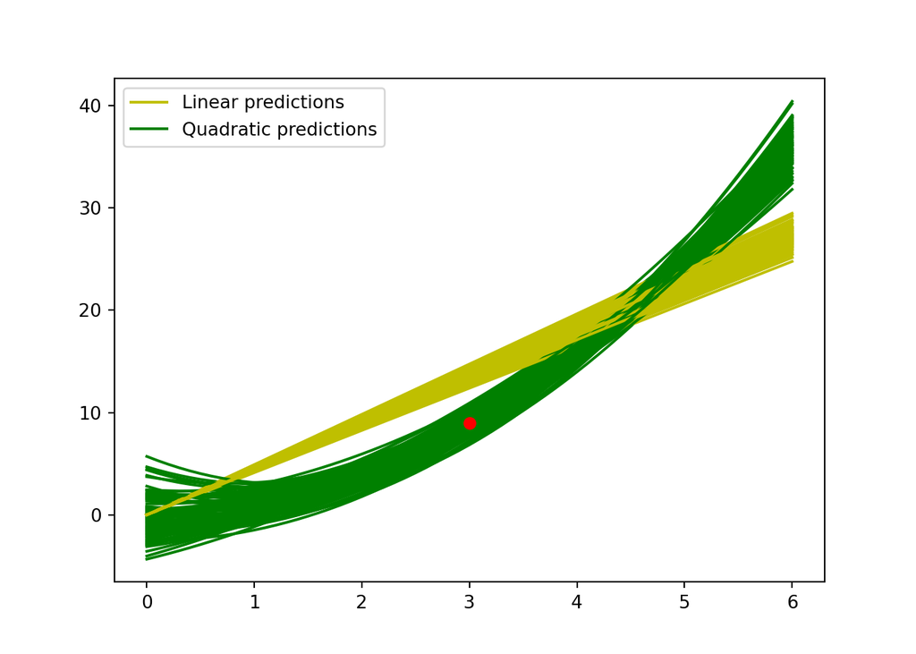

```python
plt.figure()
for i in range(0, len(quad_preds)): # Now that we've learned that you just write it on top, and run lines consecutively, we can just loop over it.
  plt.plot(x, lin_preds[i], "y-")
  plt.plot(x, quad_preds[i], "g-")
plt.plot(3, 3**2, "ro") # Plot x = 3, and the y_true, of this x
plt.legend(["Linear predictions", "Quadratic predictions"]) # Gives legend
plt.show()

# 2.3.ii
# Plotting quadratic and quintic fits
```

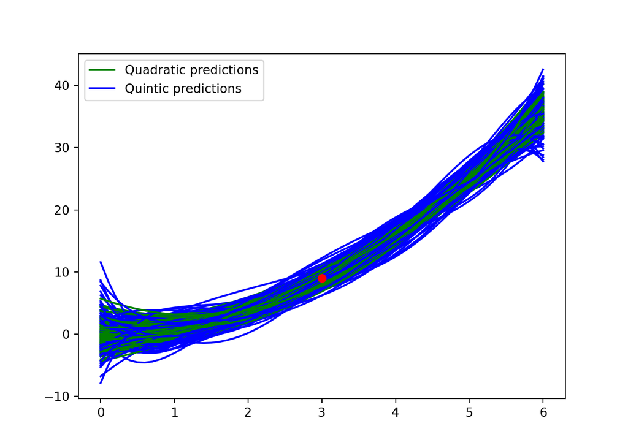

```python
plt.figure()
for i in range(0, len(quad_preds)): # Now that we've learned that you just write it on top, and run lines consecutively, we can just loop over it.
  plt.plot(x, quad_preds[i], "g-")
  plt.plot(x, quint_preds[i], "b-")
plt.plot(3, 3**2, "ro") # Plot x = 3, and the y_true, of this x
plt.legend(["Quadratic predictions", "Quintic predictions"])
plt.show()

# Which models have highest bias, and which have highest variance?
# Linear model highest bias
# Quintic model highest variance

# 2.3.iii
# Get the index with np.where(). As np.where() looks at matrices, we index to get first dimension (row), and not the second dimension
```

```python
x_highlight = np.where(x == 3)[0]

# For each of the prediction vectors for the linear models (one vector for each model), look up the value at the index where x = 3. Put this into a list.
# Take the mean of this, so we get the average prediction. Minus with the actual value, so we get the average residual value.
bias_lin = np.mean([i[x_highlight] for i in lin_preds]) - 3**2
bias_quad = np.mean([i[x_highlight] for i in quad_preds]) - 3**2
bias_quint = np.mean([i[x_highlight] for i in quint_preds]) - 3**2

# For each of the prediction vectors of the linear models (100 vectors), find look up the value at the index where x = 3. Take all these values into a list
# Then find variance of this list
var_lin = np.var([i[x_highlight] for i in lin_preds])
var_quad = np.var([i[x_highlight] for i in quad_preds])
var_quint = np.var([i[x_highlight] for i in quint_preds])

# 2.3.iv
# Inspect
bias_lin # Large residuals (large bias)
```

```
## 4.563767366318954
```

```python
bias_quad # Small residuals (lower bias)
```

```
## -0.09730514868607187
```

```python
bias_quint # Smallest residuals (lowest bias)
```

```
## -0.06943635284421745
```

```python
var_lin # Low variance (the predictions for x = 3, are similar across linear models)
```

```
## 0.2422372300169472
```

```python
var_quad # Higher variance (the predictions for x = 3, are different across models)
```

```
## 0.8206814399451829
```

```python
var_quint # Highest variance (the predictions for x = 3, are very different across models)

# 2.3.v
# Define Epsilon as Lau says
```

```
## 1.3028071012511158
```

```python
epsilon = np.random.normal(scale=5, size=100)

# Calculate MSE using formula
MSE_lin = bias_lin**2 + var_lin + np.var(epsilon)
MSE_quad = bias_quad**2 + var_quad + np.var(epsilon)
MSE_quint = bias_quint**2 + var_quint + np.var(epsilon)

# Inspect, to see MSE
# Highest for linear models, same for quad and quint models
MSE_lin
```

```
## 46.0286673708886
```

```python
MSE_quad
```

```
## 25.788607298899812
```

```python
MSE_quint
```

```
## 26.266086075341235
```